# Introduction to ggplot2

## Scales, Themes, facets

Some components are not always required but are very often used to change the appearance of graphs:

4. **Layers - stats**. Certain statistical transformations can be specified using **stats** layers. For example, if we wanted ggplot2 to create a histogram over a continuous variable, we would need to indicate how big the bins are.
5. **Scales**. **Scales** specify *how* data is mapped to the “aesthetics” of the graph. For example, if we wanted to color data points by *sex*, we can indicate what colors to use by using **scales**, otherwise ggplot2 will use a default color palette.
6. **Coordinate system**. Use this to flip axes, change to polar coordinates, or map to a geographical map (or any other image).
7. **Facets**. Graphs can be broken up into several subsets by using **facetting**
8. **Theme**. Changes the finer aspects of graphs, e.g. text size, grid lines, legend position. Sensible defaults are used.

Next we will look at some more advanced features of ggplot2 that allow for more complex and fine-tuned visualizations

We will also take this as an opportunity to explore visualizations for discrete by continuous graphs.

Here we look at case-control status (Preeclampsia vs control) and methylation

```r
table(data$diagnosis)
```

```
##
## non-PE     PE
##     18     30
```

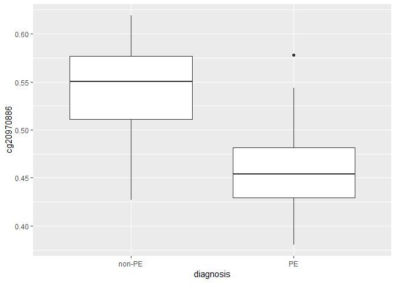

```r
# 3 essential components
ggplot(data = data, aes(x = diagnosis, y = cg20970886)) +
  geom_boxplot()
```

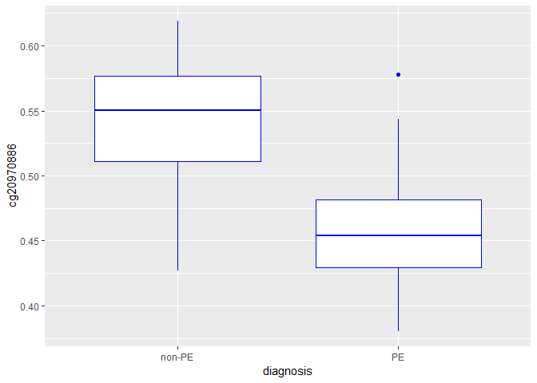

```r
# can edit as we did above
ggplot(data = data, aes(x = diagnosis, y = cg20970886)) +
  geom_boxplot(color = 'blue')
```

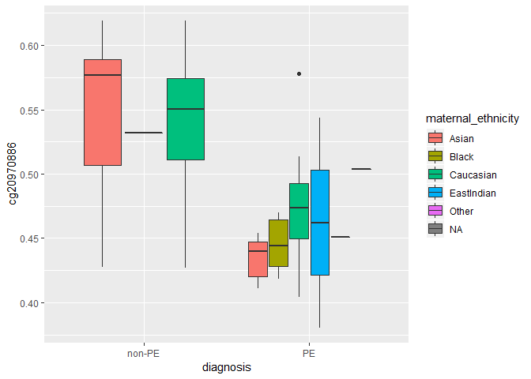

```r
ggplot(data = data, aes(x = diagnosis, y = cg20970886)) +
  geom_boxplot(aes(fill = maternal_ethnicity))
```

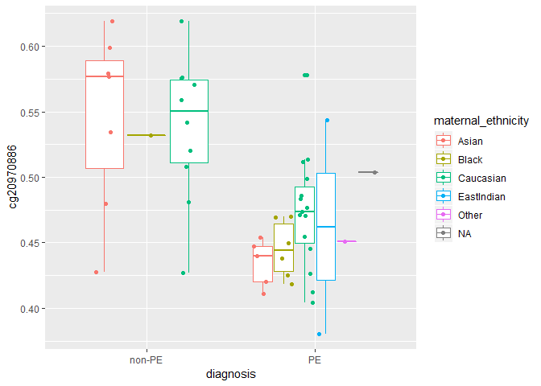

```r
# overlay jittered points
ggplot(data = data, aes(x = diagnosis, y = cg20970886, color = maternal_ethnicity)) +
  geom_boxplot() +
  geom_point(position = position_jitterdodge(dodge.width = 0.75, jitter.width = 0.1))
```

We can use scales to change which colors we want to color the boxplots by.

```r
# named vector to map colors
fill_vector <- setNames(c('#ff6d45', '#66c24a'),  c('PE', 'non-PE') )
fill_vector
```

```
##        PE    non-PE
## "#ff6d45" "#66c24a"
```

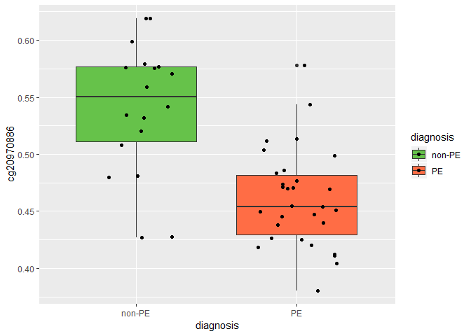

```r
# change fill color with scale_fill_manual
ggplot(data = data, aes(x = diagnosis, y = cg20970886, fill = diagnosis)) +
  geom_boxplot() +
  geom_point(position = position_jitterdodge(jitter.width = 0.5)) +
  scale_fill_manual(values = fill_vector)
```

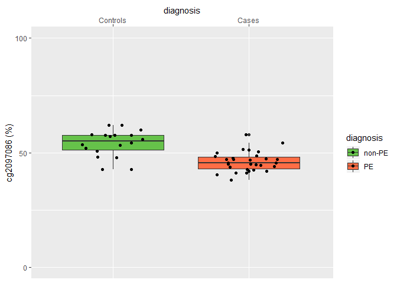

```r
# change x and y
ggplot(data = data, aes(x = diagnosis, y = cg20970886, fill = diagnosis)) +
  geom_boxplot() +
  geom_point(position = position_jitterdodge(jitter.width = 0.5)) +
  scale_fill_manual(values = fill_vector) +
  scale_x_discrete(labels = c('Controls', 'Cases'), position = 'top') +
  scale_y_continuous(limits = c(0, 1), breaks = c(0, 0.5, 1), labels = c(0, 50, 100),
                     name = 'cg2097086 (%)')
```

The *theme* allows for a customization of the non-data components of a plot. Things like the title, labels, font size, gridlines, etc.

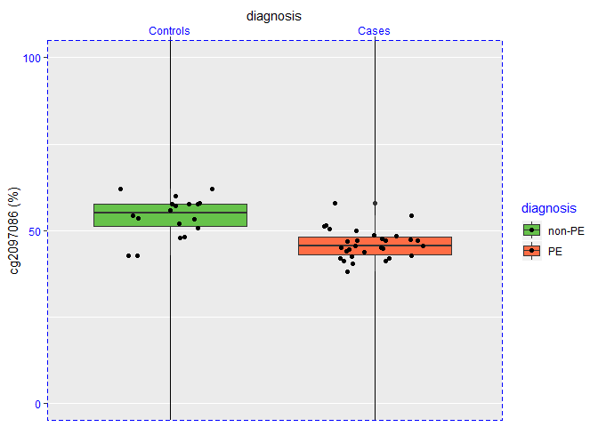

```r
## theme
ggplot(data = data, aes(x = diagnosis, y = cg20970886, fill = diagnosis)) +
  geom_boxplot() +
  geom_point(position = position_jitterdodge(jitter.width = 0.5)) +
  scale_fill_manual(values = fill_vector) +
  scale_x_discrete(labels = c('Controls', 'Cases'), position = 'top') +
  scale_y_continuous(limits = c(0, 1), breaks = c(0, 0.5, 1), labels = c(0, 50, 100),
                     name = 'cg2097086 (%)') +
  theme(axis.text = element_text(colour = 'blue'),
        legend.title = element_text(colour = 'blue'),
        panel.border = element_rect(linetype = 'dashed', fill = NA, colour = 'blue'),
        panel.grid.major.x  = element_line(colour = 'black'))
```

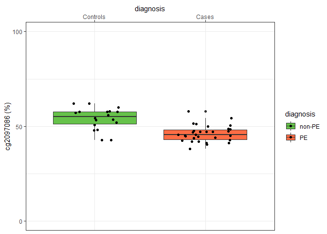

```r
ggplot(data = data, aes(x = diagnosis, y = cg20970886, fill = diagnosis)) +
  geom_boxplot() +
  geom_point(position = position_jitterdodge(jitter.width = 0.5)) +
  scale_fill_manual(values = fill_vector) +
  scale_x_discrete(labels = c('Controls', 'Cases'), position = 'top') +
  scale_y_continuous(limits = c(0, 1), breaks = c(0, 0.5, 1), labels = c(0, 50, 100),
                     name = 'cg2097086 (%)') +
  theme_bw()
```

There are customized themes that have settings preset. You can use these as a ‘base’ and edit specific elements of the theme after them.

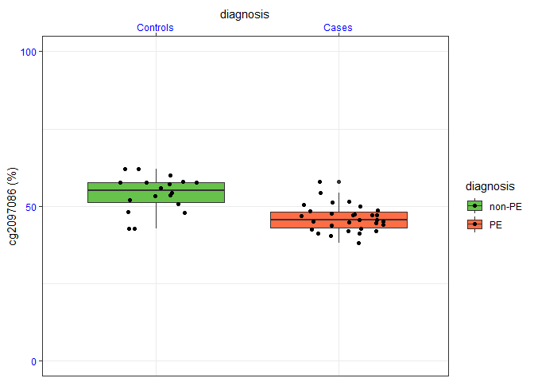

```r
ggplot(data = data, aes(x = diagnosis, y = cg20970886, fill = diagnosis)) +
  geom_boxplot() +
  geom_point(position = position_jitterdodge(jitter.width = 0.5)) +
  scale_fill_manual(values = fill_vector) +
  scale_x_discrete(labels = c('Controls', 'Cases'), position = 'top') +
  scale_y_continuous(limits = c(0, 1), breaks = c(0, 0.5, 1), labels = c(0, 50, 100),
                     name = 'cg2097086 (%)') +
  theme_bw() +
  theme(axis.text = element_text(colour = 'blue'))
```

Sometimes it is useful to create several plots, each time plotting only certain data points by a grouping variable. This can be done with **facets**.

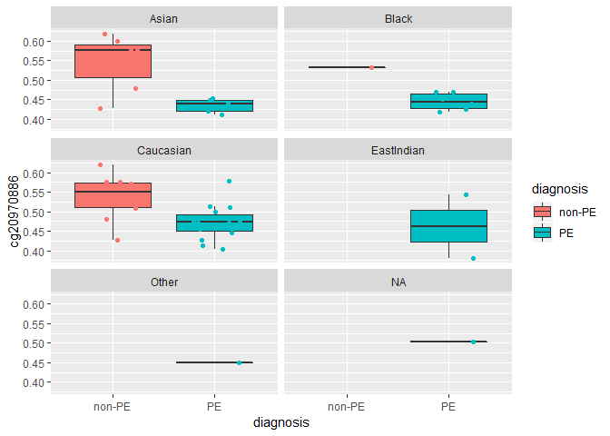

```r
ggplot(data = data, aes(x = diagnosis, y = cg20970886, fill = diagnosis)) +
  geom_boxplot(outlier.shape = NA) +
  geom_point(position = position_jitterdodge(jitter.width = 0.5),
             aes(color = diagnosis), show.legend = F)  +
  facet_wrap(vars(maternal_ethnicity), nrow = 3)
```

# Sources

Wilkinson, Leland. 2005. The Grammar of Graphics. 2nd ed. Statistics and Computing. Springer.

[ggplot2 cheatsheet](https://www.rstudio.com/wp-content/uploads/2015/03/ggplot2-cheatsheet.pdf)

[ggplot2 extensions](http://www.ggplot2-exts.org/gallery/)

[ggplot2 documentation](https://ggplot2.tidyverse.org/)

[r 4 data science data visualization chapter](https://r4ds.had.co.nz/data-visualisation.html)